# FootBall Analytics

by Dnyanada

## Preparing the data

```r
fifa <- read.csv("C:/Users/chait/Documents/CS544-R/fifa19/data.csv")
colnames(fifa)
```

```
##  [1] "ï.."                      "ID"
##  [3] "Name"                     "Age"
##  [5] "Photo"                    "Nationality"
##  [7] "Flag"                     "Overall"
##  [9] "Potential"                "Club"
## [11] "Club.Logo"                "Value"
## [13] "Wage"                     "Special"
## [15] "Preferred.Foot"           "International.Reputation"
## [17] "Weak.Foot"                "Skill.Moves"
## [19] "Work.Rate"                "Body.Type"
## [21] "Real.Face"                "Position"
## [23] "Jersey.Number"            "Joined"
## [25] "Loaned.From"              "Contract.Valid.Until"
## [27] "Height"                   "Weight"
## [29] "LS"                       "ST"
```

[output cut: 30 more lines]

```r
head(fifa)
```

```
##   ï..     ID              Name Age
## 1   0 158023          L. Messi  31
## 2   1  20801 Cristiano Ronaldo  33
## 3   2 190871         Neymar Jr  26
## 4   3 193080            De Gea  27
## 5   4 192985      K. De Bruyne  27
## 6   5 183277         E. Hazard  27
##                                            Photo Nationality
## 1 https://cdn.sofifa.org/players/4/19/158023.png   Argentina
## 2  https://cdn.sofifa.org/players/4/19/20801.png    Portugal
## 3 https://cdn.sofifa.org/players/4/19/190871.png      Brazil
## 4 https://cdn.sofifa.org/players/4/19/193080.png       Spain
## 5 https://cdn.sofifa.org/players/4/19/192985.png     Belgium
## 6 https://cdn.sofifa.org/players/4/19/183277.png     Belgium
##                                  Flag Overall Potential                Club
```

[output cut: 83 more lines]

### Checking for null values

```r
is.null(fifa)
```

```
## [1] FALSE
```

### Conversion of Wage and Value attributes

```r
fifa <- fifa %>%
        mutate(Multiplier = ifelse(str_detect(Value, "K"), 1000, ifelse(str_detect(Value, "M"), 1000000, 1))) %>%
        mutate(ValueNumeric = as.numeric(str_extract(Value, "[[:digit:]]+\\.*[[:digit:]]*")) * Multiplier) %>%
        mutate(Position = ifelse(is.na(Position), "Unknown", Position))
fifa <- fifa %>%
        mutate(WMultiplier = ifelse(str_detect(Wage, "K"), 1000, ifelse(str_detect(Wage, "M"), 1000000, 1))) %>%
        mutate(WageNumeric = as.numeric(str_extract(Wage, "[[:digit:]]+\\.*[[:digit:]]*")) * WMultiplier)
```

## • Do the analysis as in Module3 for at least one categorical variable and at least one numerical variable. Show appropriate plots for your data.

### International Reputation

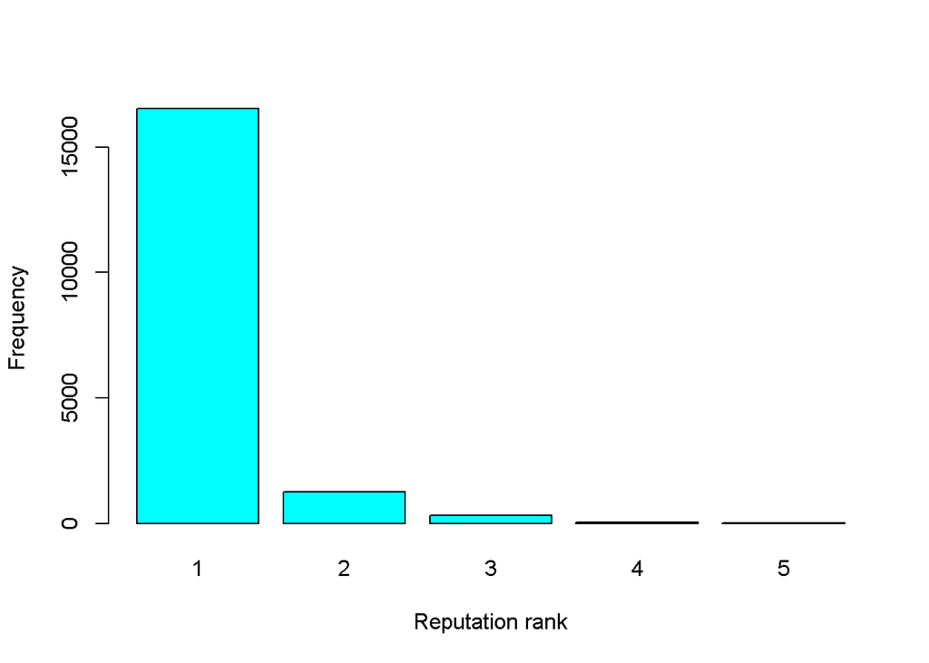

```r
barplot(table(fifa$International.Reputation),
        col = "cyan",
        xlab = "Reputation rank", ylab = "Frequency")
```

### analyzing age

```r
summary(fifa$Age)
```

```
##    Min. 1st Qu.  Median    Mean 3rd Qu.    Max.
##   16.00   21.00   25.00   25.12   28.00   45.00
```

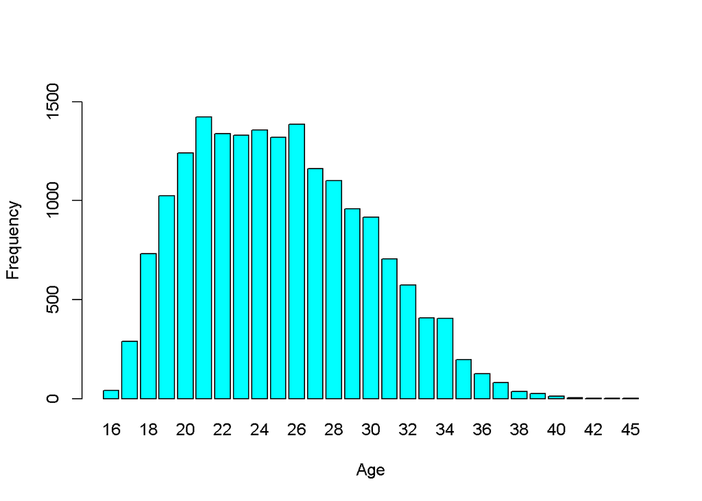

```r
barplot(table(fifa$Age),
        col = "cyan",
        xlab = "Age", ylab = "Frequency",ylim = c(0,1600))
```

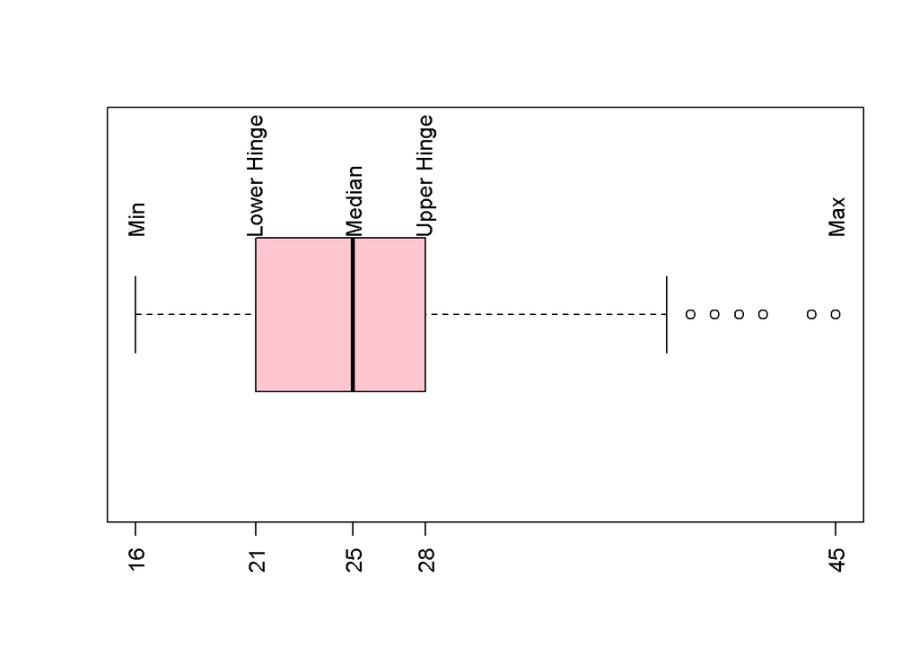

```r
boxplot(fifa$Age, horizontal = TRUE,col=hcl(0), xaxt = "n")
axis(side = 1, at = c(fivenum(fifa$Age)), labels = TRUE, las=2)
text(fivenum(fifa$Age), rep(1.2,5), srt=90, adj=0,
     labels=c("Min","Lower Hinge", "Median",
              "Upper Hinge", "Max"))
```

Maximum players are of age group 21-28

## • Do the analysis as in Module3 for at least one set of two or more variables. Show appropriate plots for your data.

### Distribution based on age and overall rating

```r
colnames(fifa)
```

```
##  [1] "ï.."                      "ID"
##  [3] "Name"                     "Age"
##  [5] "Photo"                    "Nationality"
##  [7] "Flag"                     "Overall"
##  [9] "Potential"                "Club"
## [11] "Club.Logo"                "Value"
## [13] "Wage"                     "Special"
## [15] "Preferred.Foot"           "International.Reputation"
## [17] "Weak.Foot"                "Skill.Moves"
## [19] "Work.Rate"                "Body.Type"
## [21] "Real.Face"                "Position"
## [23] "Jersey.Number"            "Joined"
## [25] "Loaned.From"              "Contract.Valid.Until"
## [27] "Height"                   "Weight"
## [29] "LS"                       "ST"
```

[output cut: 32 more lines]

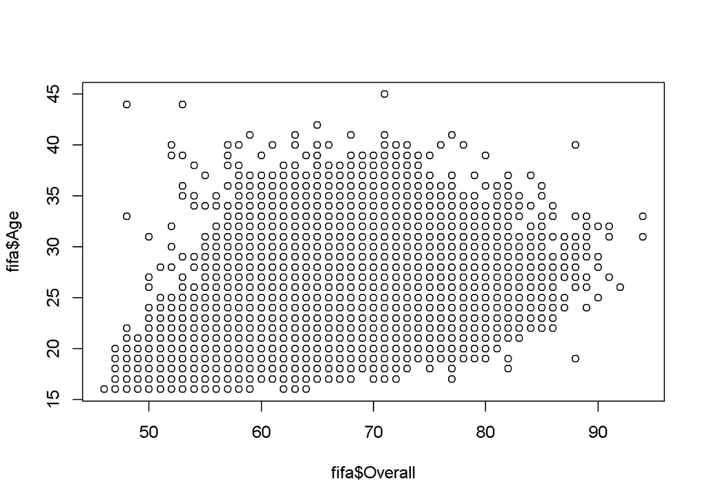

```r
plot(fifa$Overall,fifa$Age)
```

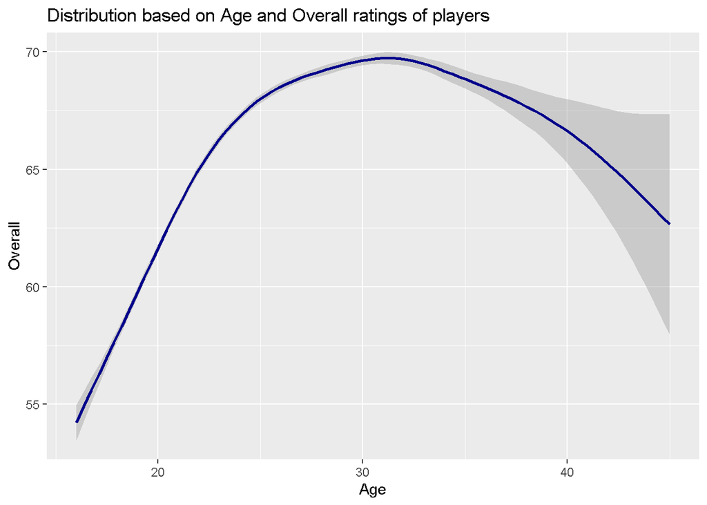

```r
g_age_overall <- ggplot(fifa, aes(Age, Overall))
g_age_overall + geom_smooth(color="darkblue") +
        ggtitle("Distribution based on Age and Overall ratings of players")
```

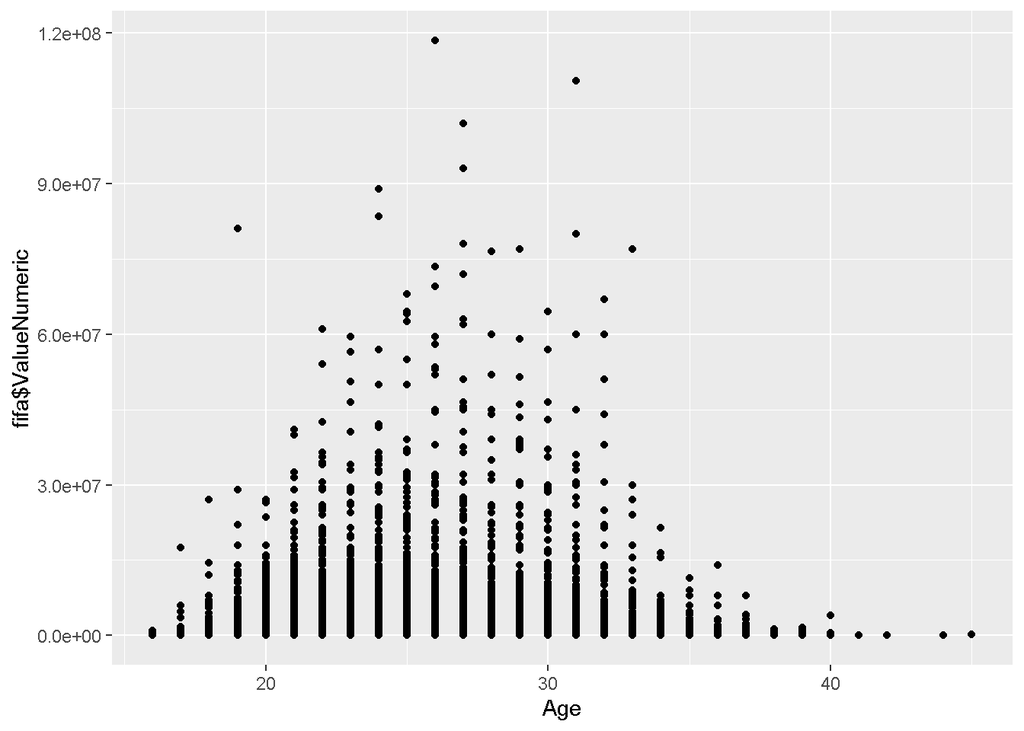

```r
ggplot(data = fifa) +
  geom_point(mapping = aes(x = Age, y = fifa$ValueNumeric))
```

### Pick one variable with numerical data and examine the distribution of the data.

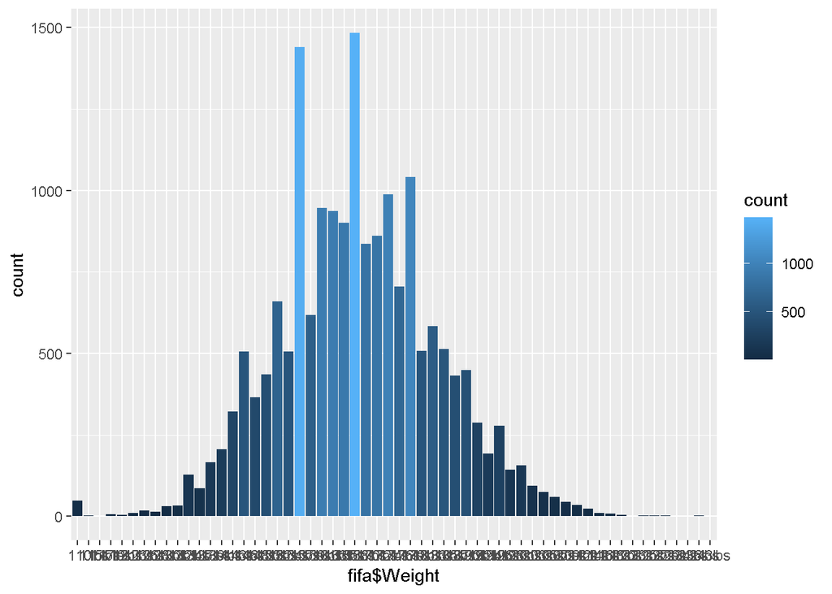

```r
ggplot(fifa,aes(fifa$Weight))+
        geom_bar(aes(fill = ..count..))
```

```r
       ggtitle("Distribution based on height of different players")
```

```
## $title
## [1] "Distribution based on height of different players"
##
## attr(,"class")
## [1] "labels"
```

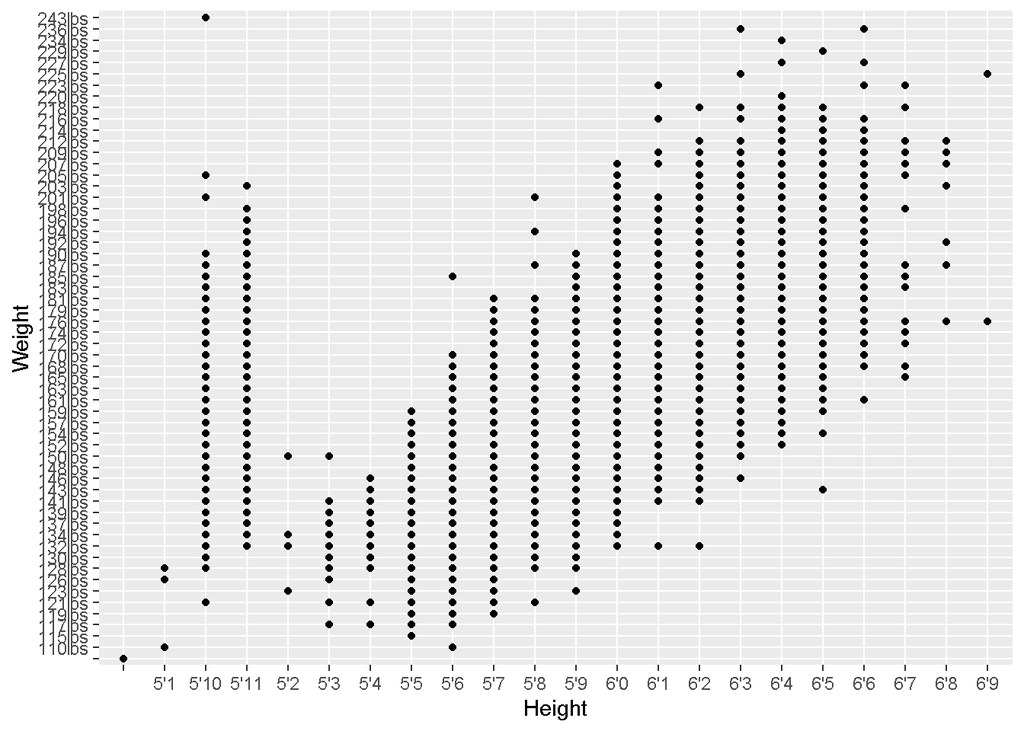

```r
ggplot(data = fifa) +
               geom_point(mapping = aes(x = Height, y = Weight))
```

### Simple random sampling

```r
n <- 15
N <- nrow(fifa)
#srswor(n,N) //Arguments n:sample size. N:population size.
s <- srswr(n,N)
RandomSamp <- fifa[s != 0, ]
table(RandomSamp$Age)
```

```
##
## 20 21 25 26 29 30 33 34
##  4  5  1  1  1  1  1  1
```

```r
s <- srswr(70, nrow(fifa))

rows <- (1:nrow(fifa))[s!=0]
rows <- rep(rows, s[s != 0])

sample.1 <- fifa[rows, ]
head(sample.1[c(2,4,14,17,22)])
```

```
##          ID Age Special Weak.Foot Position
## 169  210008  23    2184         3        6
## 361  200647  30    1976         3        2
## 407  156519  28    2106         4        6
## 1433 211101  22    1192         3        7
## 1502 231887  21    1957         4       24
## 1546 179696  29    2056         2       17
```

### without replacement

```r
s <- srswor(70, nrow(fifa))

sample.2 <- fifa[s != 0, ]
head(sample.2[c(2,4,14,17,22)])
```

```
##          ID Age Special Weak.Foot Position
## 120  207865  24    1879         3       12
## 257  205678  28    2054         4       24
## 482  198784  24    2125         4        6
## 1260 202024  26    1977         3       22
## 1647 244260  20    1833         4        2
## 1737 163665  33    1649         3       10
```

### systematic sampling

```r
N <- nrow(fifa)
n <- 50

k <- ceiling(N / n)
k
```

```
## [1] 365
```

```r
r <- sample(k, 1)
r
```

```
## [1] 32
```

```r
# select every kth item

s <- seq(r, by = k, length = n)

sample.a <- fifa[s, ]
head(sample.a[c(2,4,14,17,22)])
```

```
##          ID Age Special Weak.Foot Position
## 32   190460  26    2117         5        2
## 397  169595  27    2094         3        9
## 762  223874  23    2043         3       21
## 1127 208574  25    1951         2       14
## 1492 178115  31    1989         4       24
## 1857 213388  25    1823         3       14
```

```r
table(sample.a$Age)
```

```
##
## 17 18 19 20 21 22 23 24 25 26 27 28 29 30 31 32 33
##  1  1  2  7  4  3  3  2  4  7  5  1  4  1  3  1  1
```

```r
mean(sample.a$Age)
```

```
## [1] 24.58
```

```r
sd(sample.a$Age)
```

```
## [1] 4.046112
```

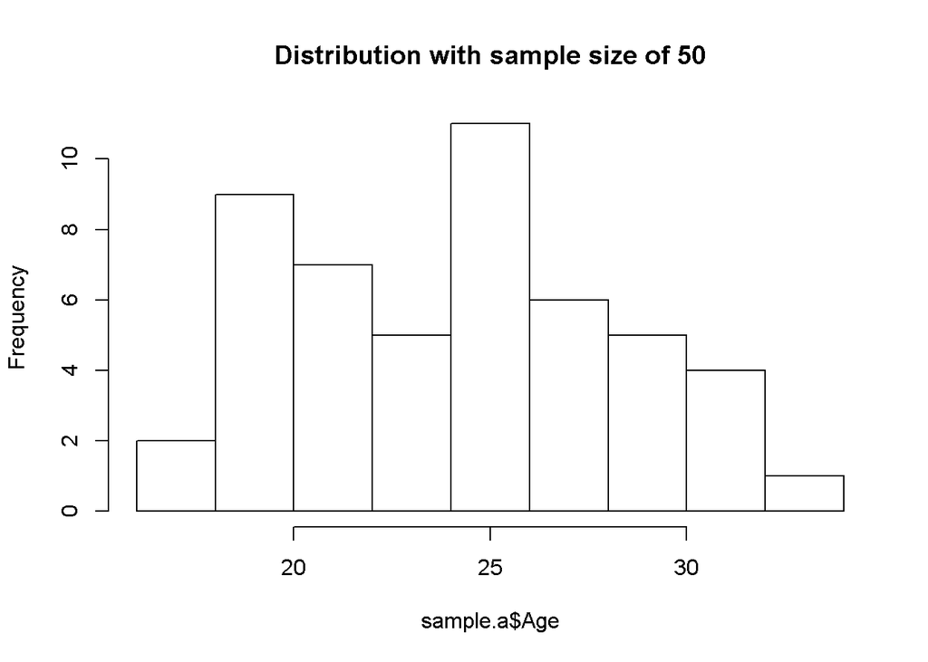

```r
hist(sample.a$Age,main = "Distribution with sample size of 50")
```

```r
N <- nrow(fifa)
n <- 100

k <- ceiling(N / n)
k
```

```
## [1] 183
```

```r
r <- sample(k, 1)
r
```

```
## [1] 42
```

```r
# select every kth item

s <- seq(r, by = k, length = n)

sample.b <- fifa[s, ]
head(sample.b[c(2,4,14,17,22)])
```

```
##         ID Age Special Weak.Foot Position
## 42    1179  40    1334         2        7
## 225  24630  35    1299         3        7
## 408 144622  33    2038         4        5
## 591 216150  26    2069         3       19
## 774 216655  26    1710         3        3
## 957 227127  23    1191         3        7
```

```r
table(sample.b$Age)
```

```
##
## 17 18 19 20 21 22 23 24 25 26 27 28 29 30 31 32 33 34 35 40
##  1  3  9 11  4  4  8  8  2  7  6  8  7  6  4  4  3  3  1  1
```

[figure not shown]

[output not shown]

[output not shown]

```r
hist(sample.b$Age,main = "Distribution with sample size of 100")
```

```r
r <- sample(k, 1)
r
```

```
## [1] 50
```

```r
# select every kth item

s <- seq(r, by = k, length = n)

sample.c <- fifa[s, ]
head(sample.c[c(2,4,14,17,22)])
```

```
##         ID Age Special Weak.Foot Position
## 50  189332  29    2230         3        9
## 142 178750  29    1333         3        7
## 234 227055  23    2023         3       24
## 326 226456  22    2071         3        2
## 418 234035  22    1991         3       19
## 510 186569  29    1137         2        7
```

```r
table(sample.c$Age)
```

```
##
## 16 17 18 19 20 21 22 23 24 25 26 27 28 29 30 31 32 33 34 35 36 41 45
##  1  2  6  8 11 17 14 16 13 13 17  7  9 18  9 13  9  4  3  3  3  1  1
```

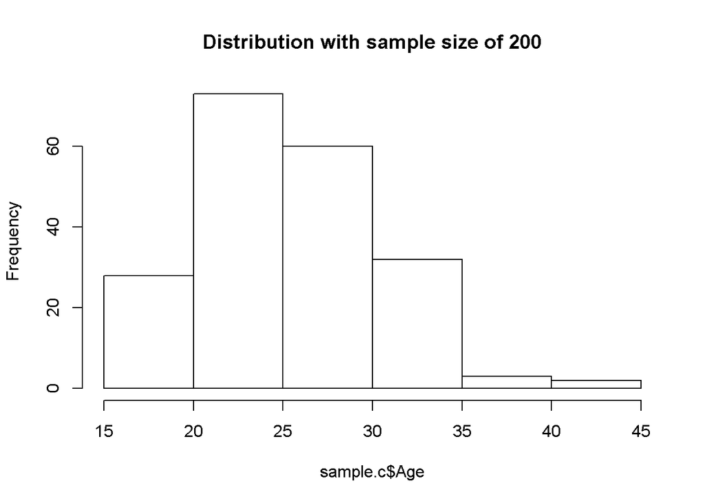

```r
hist(sample.c$Age,main = "Distribution with sample size of 200")
```